# irysy_PJ_EDA

## O Danych

Zbiór danych zawiera informacje o trzech gatunkach irysów: Iris setosa, Iris versicolor, i Iris virginica.

Dane obejmują pomiary czterech cech: długość i szerokość działki kielicha oraz długość i szerokość płatka.

Każdy wiersz w zbiorze danych reprezentuje pojedynczy kwiat, a wartości pomiarów są podane w centymetrach.

Zbiór składa się z 150 próbek, po 50 dla każdego gatunku, i jest szeroko stosowany jako podstawowy zbiór danych do testowania algorytmów klasyfikacji oraz w nauce o danych i uczeniu maszynowym.

Kolumny:

- **długość kielicha (sepal length)** - Długość kielicha w cm
- **szerokość kielicha (sepal width)** - Szerokość kielicha w cm
- **długość płatka (petal length)** - Długość płatka w cm
- **szerokość płatka (petal width)** - Szerokość płatka w cm
- **klasa (class)** - Klasa irysa (setosa, versicolor, virginica)

```python
import pandas as pd
import seaborn as sns
import matplotlib.pyplot as plt
import numpy as np
```

```python
df = pd.read_csv('25__iris.csv', sep=",")
df
```

|  | długość kielicha (sepal length) | szerokość kielicha (sepal width) | długość płatka (petal length) | szerokość płatka (petal width) | klasa (class) |
| --- | --- | --- | --- | --- | --- |
| 0 | 5.1 | 3.5 | 1.4 | 0.2 | Iris-setosa |
| 1 | 4.9 | 3.0 | 1.4 | 0.2 | Iris-setosa |
| 2 | 4.7 | 3.2 | 1.3 | 0.2 | Iris-setosa |
| 3 | 4.6 | 3.1 | 1.5 | 0.2 | Iris-setosa |
| 4 | 5.0 | 3.6 | 1.4 | 0.2 | Iris-setosa |
| ... | ... | ... | ... | ... | ... |
| 145 | 6.7 | 3.0 | 5.2 | 2.3 | Iris-virginica |
| 146 | 6.3 | 2.5 | 5.0 | 1.9 | Iris-virginica |
| 147 | 6.5 | 3.0 | 5.2 | 2.0 | Iris-virginica |
| 148 | 6.2 | 3.4 | 5.4 | 2.3 | Iris-virginica |
| 149 | 5.9 | 3.0 | 5.1 | 1.8 | Iris-virginica |

150 rows × 5 columns

# EDA - DANE DOTYCZĄCE IRYSÓW

```python
df.info()
```

```
<class 'pandas.core.frame.DataFrame'>
RangeIndex: 150 entries, 0 to 149
Data columns (total 5 columns):
 #   Column                            Non-Null Count  Dtype
---  ------                            --------------  -----
 0   długość kielicha (sepal length)   150 non-null    float64
 1   szerokość kielicha (sepal width)  150 non-null    float64
 2   długość płatka (petal length)     150 non-null    float64
 3   szerokość płatka (petal width)    150 non-null    float64
 4   klasa (class)                     150 non-null    object
dtypes: float64(4), object(1)
memory usage: 6.0+ KB
```

```python
df.sample(10)
```

|  | długość kielicha (sepal length) | szerokość kielicha (sepal width) | długość płatka (petal length) | szerokość płatka (petal width) | klasa (class) |
| --- | --- | --- | --- | --- | --- |
| 97 | 6.2 | 2.9 | 4.3 | 1.3 | Iris-versicolor |
| 40 | 5.0 | 3.5 | 1.3 | 0.3 | Iris-setosa |
| 121 | 5.6 | 2.8 | 4.9 | 2.0 | Iris-virginica |
| 138 | 6.0 | 3.0 | 4.8 | 1.8 | Iris-virginica |
| 132 | 6.4 | 2.8 | 5.6 | 2.2 | Iris-virginica |
| 41 | 4.5 | 2.3 | 1.3 | 0.3 | Iris-setosa |
| 70 | 5.9 | 3.2 | 4.8 | 1.8 | Iris-versicolor |
| 105 | 7.6 | 3.0 | 6.6 | 2.1 | Iris-virginica |
| 118 | 7.7 | 2.6 | 6.9 | 2.3 | Iris-virginica |
| 111 | 6.4 | 2.7 | 5.3 | 1.9 | Iris-virginica |

```python
df.tail(12)
```

|  | długość kielicha (sepal length) | szerokość kielicha (sepal width) | długość płatka (petal length) | szerokość płatka (petal width) | klasa (class) |
| --- | --- | --- | --- | --- | --- |
| 138 | 6.0 | 3.0 | 4.8 | 1.8 | Iris-virginica |
| 139 | 6.9 | 3.1 | 5.4 | 2.1 | Iris-virginica |
| 140 | 6.7 | 3.1 | 5.6 | 2.4 | Iris-virginica |
| 141 | 6.9 | 3.1 | 5.1 | 2.3 | Iris-virginica |
| 142 | 5.8 | 2.7 | 5.1 | 1.9 | Iris-virginica |
| 143 | 6.8 | 3.2 | 5.9 | 2.3 | Iris-virginica |
| 144 | 6.7 | 3.3 | 5.7 | 2.5 | Iris-virginica |
| 145 | 6.7 | 3.0 | 5.2 | 2.3 | Iris-virginica |
| 146 | 6.3 | 2.5 | 5.0 | 1.9 | Iris-virginica |
| 147 | 6.5 | 3.0 | 5.2 | 2.0 | Iris-virginica |
| 148 | 6.2 | 3.4 | 5.4 | 2.3 | Iris-virginica |
| 149 | 5.9 | 3.0 | 5.1 | 1.8 | Iris-virginica |

```python
df.columns
```

```
Index(['długość kielicha (sepal length)', 'szerokość kielicha (sepal width)',
       'długość płatka (petal length)', 'szerokość płatka (petal width)',
       'klasa (class)'],
      dtype='object')
```

```python
df.isnull().sum()
```

```
długość kielicha (sepal length)     0
szerokość kielicha (sepal width)    0
długość płatka (petal length)       0
szerokość płatka (petal width)      0
klasa (class)                       0
dtype: int64
```

## Jakie wartości unikatowe zawiera ten zestaw danych?

```python
df.nunique()
```

```
długość kielicha (sepal length)     35
szerokość kielicha (sepal width)    23
długość płatka (petal length)       43
szerokość płatka (petal width)      22
klasa (class)                        3
dtype: int64
```

#### Z powyższych danych można wnioskować, że kwiaty są najbardziej zróżnicowanej pod względem długości płatka.

```python
df["klasa (class)"]
```

```
0         Iris-setosa
1         Iris-setosa
2         Iris-setosa
3         Iris-setosa
4         Iris-setosa
            ...
145    Iris-virginica
146    Iris-virginica
147    Iris-virginica
148    Iris-virginica
149    Iris-virginica
Name: klasa (class), Length: 150, dtype: object
```

```python
df.groupby('klasa (class)', as_index=False)['długość kielicha (sepal length)'].nunique()
```

|  | klasa (class) | długość kielicha (sepal length) |
| --- | --- | --- |
| 0 | Iris-setosa | 15 |
| 1 | Iris-versicolor | 21 |
| 2 | Iris-virginica | 21 |

```python
df.groupby('klasa (class)', as_index=False)['szerokość kielicha (sepal width)'].nunique()
```

|  | klasa (class) | szerokość kielicha (sepal width) |
| --- | --- | --- |
| 0 | Iris-setosa | 16 |
| 1 | Iris-versicolor | 14 |
| 2 | Iris-virginica | 13 |

```python
df.groupby('klasa (class)', as_index=False)['długość płatka (petal length)'].nunique()
```

|  | klasa (class) | długość płatka (petal length) |
| --- | --- | --- |
| 0 | Iris-setosa | 9 |
| 1 | Iris-versicolor | 19 |
| 2 | Iris-virginica | 20 |

```python
df.groupby('klasa (class)', as_index=False)['szerokość płatka (petal width)'].nunique()
```

|  | klasa (class) | szerokość płatka (petal width) |
| --- | --- | --- |
| 0 | Iris-setosa | 6 |
| 1 | Iris-versicolor | 9 |
| 2 | Iris-virginica | 12 |

#### Z danych unikatowych w każdej klasie irysów wynika, że kwiaty w klasie Iris virginica są najbardziej zróżnicowane pod względem kształtu, najmniej zróżnicowane wartości posiadają zaś kwiaty z klasy Irys setosa.

## Ile rodzajów klas irysów zawierają dane?

```python
df["klasa (class)"].nunique()
```

```
3
```

## Ile danych zawiera każda z trzech klas?

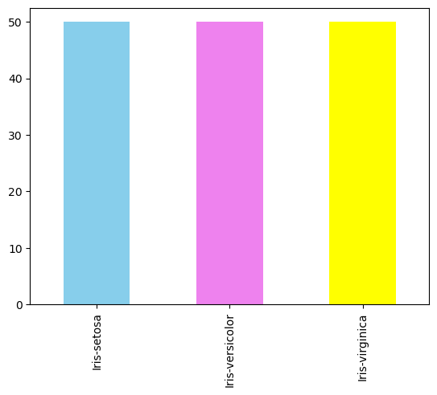

```python
df["klasa (class)"].value_counts().plot(kind='bar', color=['skyblue', 'violet', 'yellow'])
```

## Który z rodzajów irysów ma najbardziej okrągły kształt płatka?

```python
df.corr(numeric_only=True)
```

|  | długość kielicha (sepal length) | szerokość kielicha (sepal width) | długość płatka (petal length) | szerokość płatka (petal width) |
| --- | --- | --- | --- | --- |
| długość kielicha (sepal length) | 1.000000 | -0.109369 | 0.871754 | 0.817954 |
| szerokość kielicha (sepal width) | -0.109369 | 1.000000 | -0.420516 | -0.356544 |
| długość płatka (petal length) | 0.871754 | -0.420516 | 1.000000 | 0.962757 |
| szerokość płatka (petal width) | 0.817954 | -0.356544 | 0.962757 | 1.000000 |

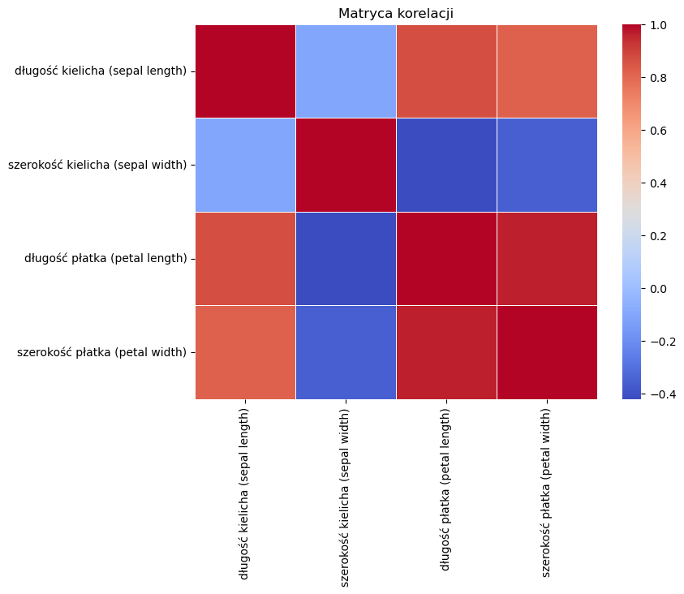

```python
corr = df.corr(numeric_only=True)
plt.figure(figsize=(8, 6))
sns.heatmap(corr, cmap='coolwarm', fmt=".2f", linewidths=0.5)
plt.title("Matryca korelacji")
plt.show()
```

#### Szerokość płatka koreluje z długością płatką. Zobaczmy, jak ta korelacja wygląda w poszczególnych klasach irysów.

```python
df.iloc[1:50].corr(numeric_only=True)
```

|  | długość kielicha (sepal length) | szerokość kielicha (sepal width) | długość płatka (petal length) | szerokość płatka (petal width) |
| --- | --- | --- | --- | --- |
| długość kielicha (sepal length) | 1.000000 | 0.746498 | 0.266497 | 0.282074 |
| szerokość kielicha (sepal width) | 0.746498 | 1.000000 | 0.178687 | 0.282444 |
| długość płatka (petal length) | 0.266497 | 0.178687 | 1.000000 | 0.304120 |
| szerokość płatka (petal width) | 0.282074 | 0.282444 | 0.304120 | 1.000000 |

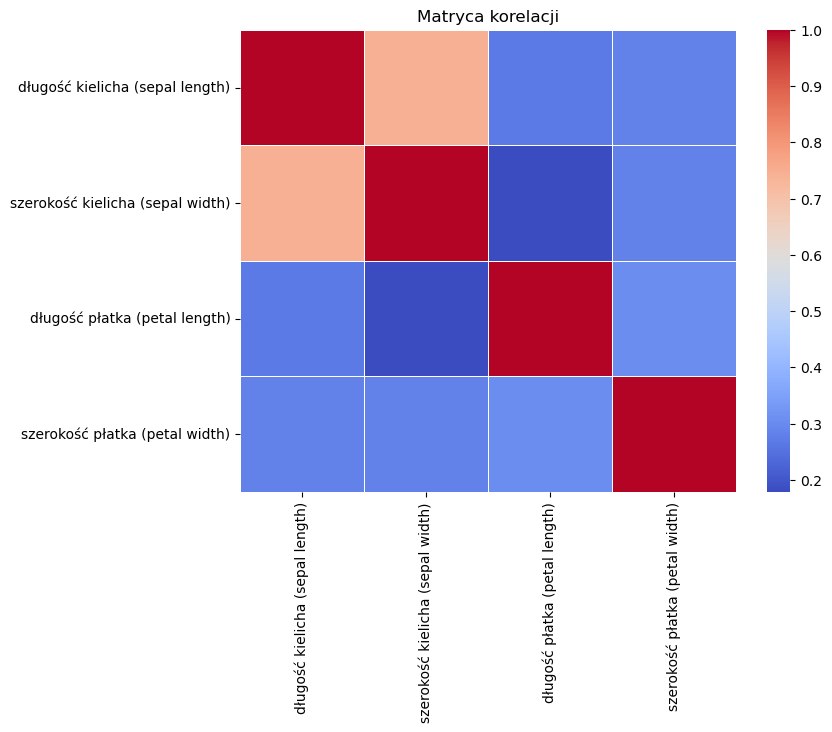

```python
matryca_setosa = df.iloc[1:50].corr(numeric_only=True)
plt.figure(figsize=(8, 6))
sns.heatmap(matryca_setosa, cmap='coolwarm', fmt=".2f", linewidths=0.5)
plt.title("Matryca korelacji")
plt.show()
```

### Korelacja długości płatka z szerokością płatka w klasie irys setosa wynosi ~ 0.3.

```python
df.iloc[50:100].corr(numeric_only=True)
```

|  | długość kielicha (sepal length) | szerokość kielicha (sepal width) | długość płatka (petal length) | szerokość płatka (petal width) |
| --- | --- | --- | --- | --- |
| długość kielicha (sepal length) | 1.000000 | 0.525911 | 0.754049 | 0.546461 |
| szerokość kielicha (sepal width) | 0.525911 | 1.000000 | 0.560522 | 0.663999 |
| długość płatka (petal length) | 0.754049 | 0.560522 | 1.000000 | 0.786668 |
| szerokość płatka (petal width) | 0.546461 | 0.663999 | 0.786668 | 1.000000 |

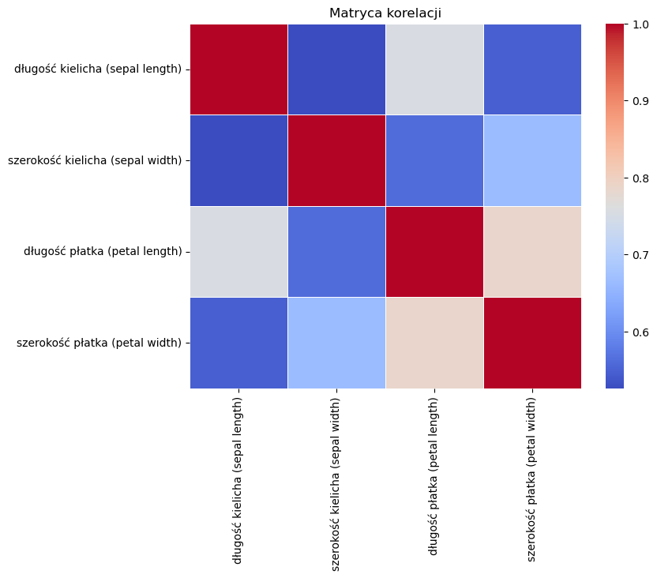

```python
matryca_versicolor = df.iloc[50:100].corr(numeric_only=True)
plt.figure(figsize=(8, 6))
sns.heatmap(matryca_versicolor, cmap='coolwarm', fmt=".2f", linewidths=0.5)
plt.title("Matryca korelacji")
plt.show()
```

### Korelacja między długością płatka a szerokością wpłatka w klasie irysów versicolor wynosi ~ 0.8.

```python
df.iloc[100:150].corr(numeric_only=True)
```

|  | długość kielicha (sepal length) | szerokość kielicha (sepal width) | długość płatka (petal length) | szerokość płatka (petal width) |
| --- | --- | --- | --- | --- |
| długość kielicha (sepal length) | 1.000000 | 0.457228 | 0.864225 | 0.281108 |
| szerokość kielicha (sepal width) | 0.457228 | 1.000000 | 0.401045 | 0.537728 |
| długość płatka (petal length) | 0.864225 | 0.401045 | 1.000000 | 0.322108 |
| szerokość płatka (petal width) | 0.281108 | 0.537728 | 0.322108 | 1.000000 |

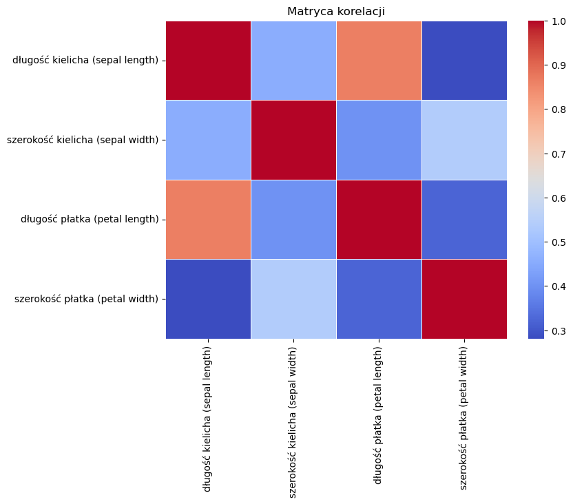

```python
matryca_virginica = df.iloc[100:150].corr(numeric_only=True)
plt.figure(figsize=(8, 6))
sns.heatmap(matryca_virginica, cmap='coolwarm', fmt=".2f", linewidths=0.5)
plt.title("Matryca korelacji")
plt.show()
```

### Korelacja między długością płatka a szerokością płatka w klasie irysów virginica wynosi ~ 0.3.

#### Możemy wnioskować, że najokrąglejsze płatki będą miały kwiaty z klasy irysów versicolor.

## Który rodzaj irysów ma największe kwiaty?

```python
df.groupby('klasa (class)', as_index=False)['szerokość kielicha (sepal width)'].mean()
```

|  | klasa (class) | szerokość kielicha (sepal width) |
| --- | --- | --- |
| 0 | Iris-setosa | 3.418 |
| 1 | Iris-versicolor | 2.770 |
| 2 | Iris-virginica | 2.974 |

```python
df.groupby('klasa (class)', as_index=False)['długość kielicha (sepal length)'].mean()
```

|  | klasa (class) | długość kielicha (sepal length) |
| --- | --- | --- |
| 0 | Iris-setosa | 5.006 |
| 1 | Iris-versicolor | 5.936 |
| 2 | Iris-virginica | 6.588 |

```python
df.groupby('klasa (class)', as_index=False)['szerokość płatka (petal width)'].mean()
```

|  | klasa (class) | szerokość płatka (petal width) |
| --- | --- | --- |
| 0 | Iris-setosa | 0.244 |
| 1 | Iris-versicolor | 1.326 |
| 2 | Iris-virginica | 2.026 |

```python
df.groupby('klasa (class)', as_index=False)['długość płatka (petal length)'].mean()
```

|  | klasa (class) | długość płatka (petal length) |
| --- | --- | --- |
| 0 | Iris-setosa | 1.464 |
| 1 | Iris-versicolor | 4.260 |
| 2 | Iris-virginica | 5.552 |

## Jakie są maksymalne i minimalne wartości w każdej klasie irysów?

```python
df.groupby('klasa (class)', as_index=False)['szerokość kielicha (sepal width)'].max()
```

|  | klasa (class) | szerokość kielicha (sepal width) |
| --- | --- | --- |
| 0 | Iris-setosa | 4.4 |
| 1 | Iris-versicolor | 3.4 |
| 2 | Iris-virginica | 3.8 |

```python
df.groupby('klasa (class)', as_index=False)['długość kielicha (sepal length)'].max()
```

|  | klasa (class) | długość kielicha (sepal length) |
| --- | --- | --- |
| 0 | Iris-setosa | 5.8 |
| 1 | Iris-versicolor | 7.0 |
| 2 | Iris-virginica | 7.9 |

```python
df.groupby('klasa (class)', as_index=False)['szerokość płatka (petal width)'].max()
```

|  | klasa (class) | szerokość płatka (petal width) |
| --- | --- | --- |
| 0 | Iris-setosa | 0.6 |
| 1 | Iris-versicolor | 1.8 |
| 2 | Iris-virginica | 2.5 |

```python
df.groupby('klasa (class)', as_index=False)['długość płatka (petal length)'].max()
```

|  | klasa (class) | długość płatka (petal length) |
| --- | --- | --- |
| 0 | Iris-setosa | 1.9 |
| 1 | Iris-versicolor | 5.1 |
| 2 | Iris-virginica | 6.9 |

```python
df.groupby('klasa (class)', as_index=False)['szerokość kielicha (sepal width)'].min()
```

|  | klasa (class) | szerokość kielicha (sepal width) |
| --- | --- | --- |
| 0 | Iris-setosa | 2.3 |
| 1 | Iris-versicolor | 2.0 |
| 2 | Iris-virginica | 2.2 |

```python
df.groupby('klasa (class)', as_index=False)['długość kielicha (sepal length)'].min()
```

|  | klasa (class) | długość kielicha (sepal length) |
| --- | --- | --- |
| 0 | Iris-setosa | 4.3 |
| 1 | Iris-versicolor | 4.9 |
| 2 | Iris-virginica | 4.9 |

```python
df.groupby('klasa (class)', as_index=False)['szerokość płatka (petal width)'].min()
```

|  | klasa (class) | szerokość płatka (petal width) |
| --- | --- | --- |
| 0 | Iris-setosa | 0.1 |
| 1 | Iris-versicolor | 1.0 |
| 2 | Iris-virginica | 1.4 |

```python
df.groupby('klasa (class)', as_index=False)['długość płatka (petal length)'].min()
```

|  | klasa (class) | długość płatka (petal length) |
| --- | --- | --- |
| 0 | Iris-setosa | 1.0 |
| 1 | Iris-versicolor | 3.0 |
| 2 | Iris-virginica | 4.5 |

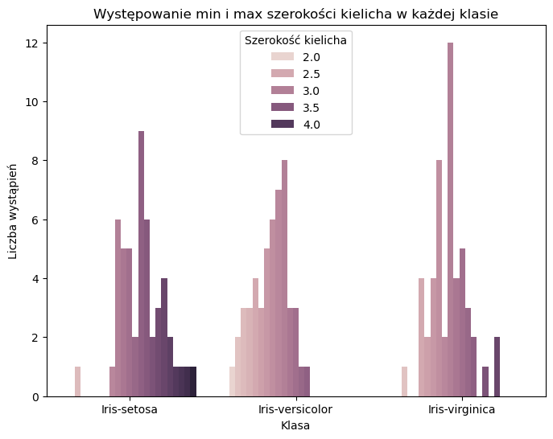

```python
df_clean = df.dropna(subset=['klasa (class)', 'szerokość kielicha (sepal width)'])
plt.figure(figsize=(8, 6))
sns.countplot(data=df_clean, x='klasa (class)', hue='szerokość kielicha (sepal width)')
plt.title('Występowanie min i max szerokości kielicha w każdej klasie')
plt.xlabel('Klasa')
plt.ylabel('Liczba wystąpień')
plt.legend(title='Szerokość kielicha')
plot_filename = "szerokosc_klasa_max.png"
plt.savefig(plot_filename)
```

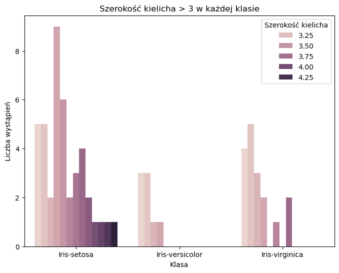

```python
df_clean = df[df['szerokość kielicha (sepal width)'] > 3]
plt.figure(figsize=(8, 6))
sns.countplot(data=df_clean, x='klasa (class)', hue='szerokość kielicha (sepal width)')
plt.title('Szerokość kielicha > 3 w każdej klasie')
plt.xlabel('Klasa')
plt.ylabel('Liczba wystąpień')
plt.legend(title='Szerokość kielicha')
plot_filename = "szerokosc3_klasa_max.png"
plt.savefig(plot_filename)
```

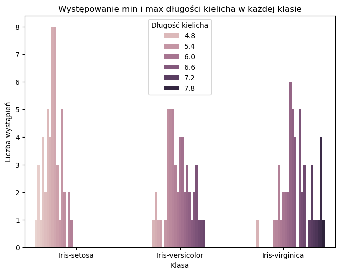

```python
df_clean = df.dropna(subset=['klasa (class)', 'długość kielicha (sepal length)'])
plt.figure(figsize=(8, 6))
sns.countplot(data=df_clean, x='klasa (class)', hue='długość kielicha (sepal length)')
plt.title('Występowanie min i max długości kielicha w każdej klasie')
plt.xlabel('Klasa')
plt.ylabel('Liczba wystąpień')
plt.legend(title='Długość kielicha')
plot_filename = "długość_klasa_max.png"
plt.savefig(plot_filename)
```

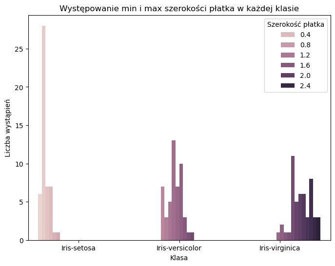

```python
df_clean = df.dropna(subset=['klasa (class)', 'szerokość płatka (petal width)'])
plt.figure(figsize=(8, 6))
sns.countplot(data=df_clean, x='klasa (class)', hue='szerokość płatka (petal width)')
plt.title('Występowanie min i max szerokości płatka w każdej klasie')
plt.xlabel('Klasa')
plt.ylabel('Liczba wystąpień')
plt.legend(title='Szerokość płatka')
plot_filename = "szerokosc_platka_klasa_max.png"
plt.savefig(plot_filename)
```

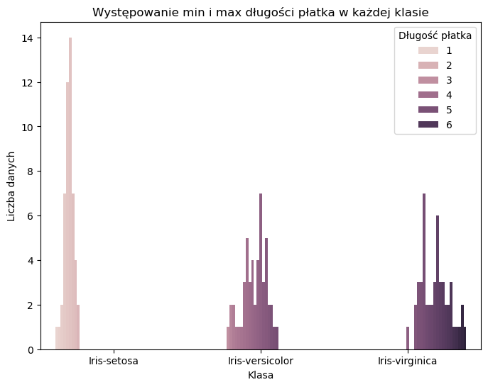

```python
df_clean = df.dropna(subset=['klasa (class)', 'długość płatka (petal length)'])
plt.figure(figsize=(8, 6))
sns.countplot(data=df_clean, x='klasa (class)', hue='długość płatka (petal length)')
plt.title('Występowanie min i max długości płatka w każdej klasie')
plt.xlabel('Klasa')
plt.ylabel('Liczba danych')
plt.legend(title='Długość płatka')
plot_filename = "długość_platka_klasa_max.png"
plt.savefig(plot_filename)
```

### Zestawienie danych dla każdej klasy irysów wygeneruję w pairplocie.

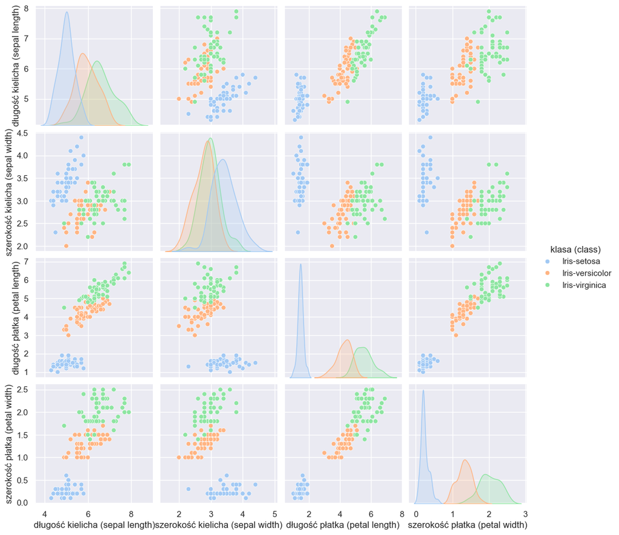

```python
sns.pairplot(df, hue='klasa (class)', palette="pastel")
```

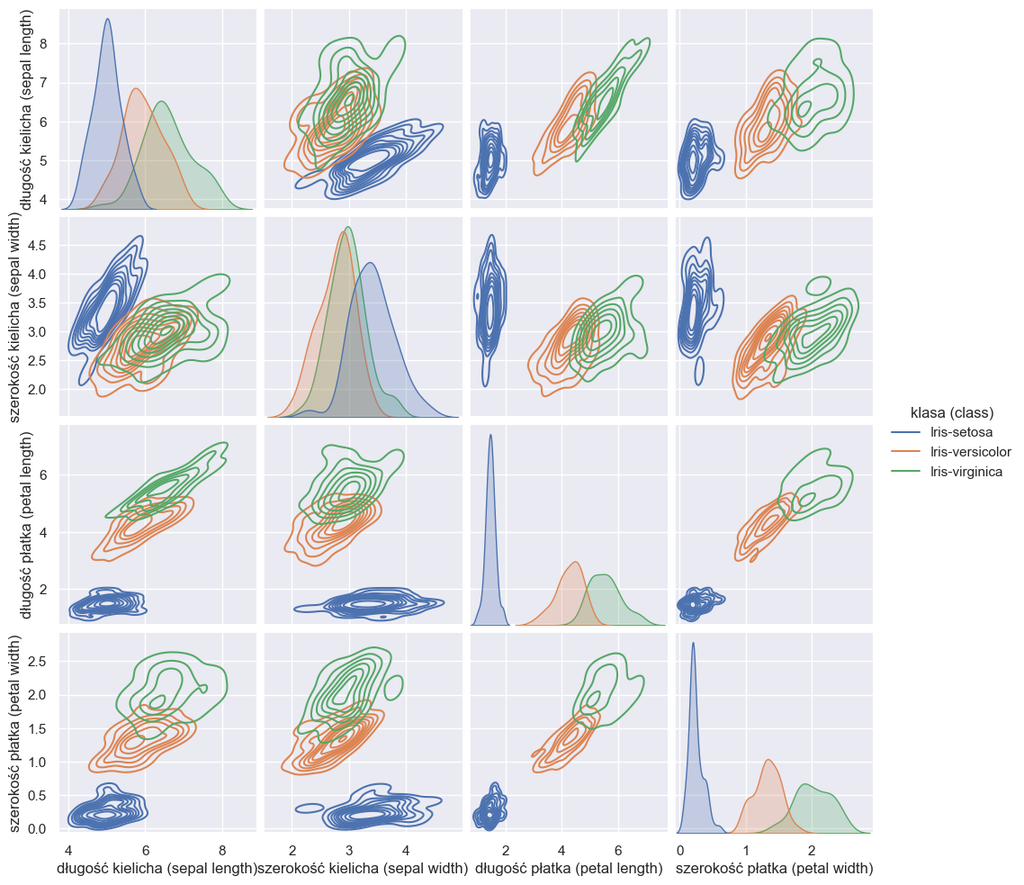

```python
sns.pairplot(df, kind="kde", hue='klasa (class)')
```

```python
df.max()
```

```
długość kielicha (sepal length)                7.9
szerokość kielicha (sepal width)               4.4
długość płatka (petal length)                  6.9
szerokość płatka (petal width)                 2.5
klasa (class)                       Iris-virginica
dtype: object
```

```python
df.min()
```

```
długość kielicha (sepal length)             4.3
szerokość kielicha (sepal width)            2.0
długość płatka (petal length)               1.0
szerokość płatka (petal width)              0.1
klasa (class)                       Iris-setosa
dtype: object
```

## Możemy wnioskować, że najwieksze kwiaty to Irysy virginica, a najdrobniejsze - Irysy setosa.

## Które klasy irysów najbardziej się wyróżniają?

```python
df.groupby('klasa (class)', as_index=False)['szerokość płatka (petal width)'].std()
```

|  | klasa (class) | szerokość płatka (petal width) |
| --- | --- | --- |
| 0 | Iris-setosa | 0.107210 |
| 1 | Iris-versicolor | 0.197753 |
| 2 | Iris-virginica | 0.274650 |

```python
df.groupby('klasa (class)', as_index=False)['długość płatka (petal length)'].std()
```

|  | klasa (class) | długość płatka (petal length) |
| --- | --- | --- |
| 0 | Iris-setosa | 0.173511 |
| 1 | Iris-versicolor | 0.469911 |
| 2 | Iris-virginica | 0.551895 |

```python
df.groupby('klasa (class)', as_index=False)['długość kielicha (sepal length)'].std()
```

|  | klasa (class) | długość kielicha (sepal length) |
| --- | --- | --- |
| 0 | Iris-setosa | 0.352490 |
| 1 | Iris-versicolor | 0.516171 |
| 2 | Iris-virginica | 0.635880 |

```python
df.groupby('klasa (class)', as_index=False)['szerokość kielicha (sepal width)'].std()
```

|  | klasa (class) | szerokość kielicha (sepal width) |
| --- | --- | --- |
| 0 | Iris-setosa | 0.381024 |
| 1 | Iris-versicolor | 0.313798 |
| 2 | Iris-virginica | 0.322497 |

#### Z tych danych również wynika, że Irys versicolor i Irys virginica będą kwiatami podobnymi do siebie pod względem wielkości i kształtu płatków i kielicha, podczas gdy Irysy setosa będą od nich mniejsze.

## Wnioski

### Kwiaty irysów versicolor i virginica najłatwiej ze sobą pomylić

#### • te klasy irysów posiadają zbliżone wartości wielkości płatka i kielicha, jednak irysy virginica są nieznacznie większe

### Rekomendacje

#### • w celu urozmaicenia hodowli kwiatów z grupy irysów zaleca się kupić nasiona irysa versicolor i irysa setosa

#### • w przypadku braku w hurtowni nasion irysów versicolor można zastąpić je porównywalnymi nasionami kwiatów virginica

#### Poniżej przykładowe fotografie każdego z klas irysów.

- Irys setosa

[figure not shown]

- Irys versicolor

[figure not shown]

- Irys virginica

[figure not shown]

```python
pip install nbconvert
```

```python
!jupyter nbconvert --to html "25__zadanie_domowe__modul_4_1 PJ.12.02.ipynb"
```

```
[NbConvertApp] Converting notebook 25__zadanie_domowe__modul_4_1 PJ.12.02.ipynb to html
[NbConvertApp] WARNING | Alternative text is missing on 12 image(s).
[NbConvertApp] Writing 1837522 bytes to 25__zadanie_domowe__modul_4_1 PJ.12.02.html
```